# Data Type and Structure

Multivariate Data Analysis

Description Data Type and Structure of Multivariate Data

Yeongeun Jeon  
09-16-2022

# **1. 기초 행렬 대수**

- 다변량 분석방법을 이해하는데 필수적인 행렬 대수(Matrix Algebra)의 기본적 개념에 대해 알아보고자 한다.

## **1-1. 행렬의 정의**

- 행렬(Matrix) : 숫자를 행과 열에 맞추어 직사각형 또는 정사각형 모양으로 정렬한 배열
  - 배열된 수를 그 행렬의 성분(Entries)이라고 한다.
    $$\mathbf{X}_{n\times p} = \begin{pmatrix}
    x_{11} & x_{12} & \ldots & x_{1p}\\
    x_{21} & x_{22} & \ldots & x_{2p}\\
    \vdots & \vdots & \vdots & \vdots \\
    x_{n1} & x_{n2} & \ldots & x_{np}\\
    \end{pmatrix}$$
- 행렬은 열벡터 또는 행벡터로 구성된다.
  - 열벡터 : 한 개의 열로만 이루어진 행렬
    $$\mathbf{X}_{n\times 1} = \begin{pmatrix}
    x_{1}\\
    x_{2} \\
    \vdots \\
    x_{n} \\
    \end{pmatrix}$$
  - 행벡터 : 한 개의 행으로만 이루어진 행렬
    $$\begin{align}
    \mathbf{X}_{1\times n} = \left(x_{1} \ldots x_{n}\right)
    \end{align}$$
- R에서 행렬을 생성하기 위해서는 함수 `matrix(성분, nrow, byrow = FALSE)`를 이용한다.
  - `성분` : 행렬의 성분
  - `nrow` : 행의 수
  - `byrow` : 성분을 행으로 나열할 것인지를 나타내는 논리값

```
# 예제 11
## 행렬 성분
entries <- c(1, 5, 10, 3, 2, 9, 5, 14, 38, 18, 26, 5)

## 행렬 생성
matrix(entries, nrow = 3, byrow = FALSE)
```

```
     [,1] [,2] [,3] [,4]
[1,]    1    3    5   18
[2,]    5    2   14   26
[3,]   10    9   38    5
```

```
matrix(entries, nrow = 3, byrow = TRUE)
```

```
     [,1] [,2] [,3] [,4]
[1,]    1    5   10    3
[2,]    2    9    5   14
[3,]   38   18   26    5
```

```
# 예제 22
## 행렬 성분
entries <- 1:30

## 행렬 생성
matrix(entries, nrow = 6, byrow = FALSE)
```

```
     [,1] [,2] [,3] [,4] [,5]
[1,]    1    7   13   19   25
[2,]    2    8   14   20   26
[3,]    3    9   15   21   27
[4,]    4   10   16   22   28
[5,]    5   11   17   23   29
[6,]    6   12   18   24   30
```

```
matrix(entries, nrow = 6, byrow = TRUE)
```

```
     [,1] [,2] [,3] [,4] [,5]
[1,]    1    2    3    4    5
[2,]    6    7    8    9   10
[3,]   11   12   13   14   15
[4,]   16   17   18   19   20
[5,]   21   22   23   24   25
[6,]   26   27   28   29   30
```

- R에서 기본적으로 제공하는 주요 행렬연산함수는 다음과 같다.

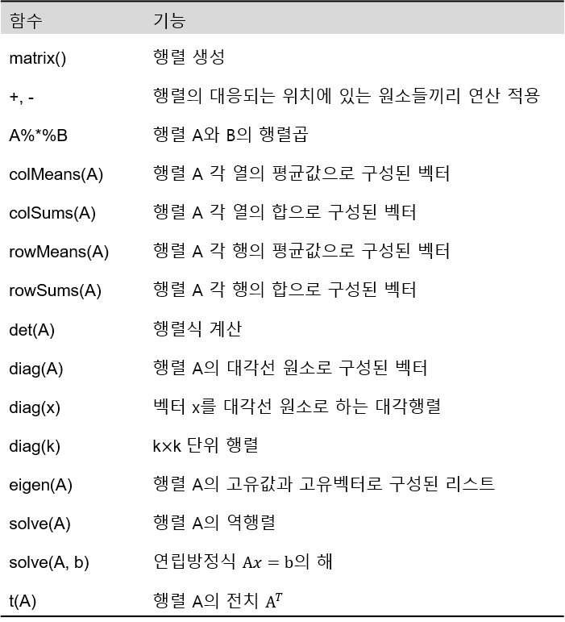

### **1-1-1. 특정 형태를 갖는 행렬**

#### **정방행렬**

- 정방행렬(Square Matrix) : 행과 열의 크기가 같은 정사각형꼴의 행렬
  $$\mathbf{X}_{n\times n} = \begin{pmatrix}
  x_{11} & x_{12} & \ldots & x_{1n}\\
  x_{21} & x_{22} & \ldots & x_{2n}\\
  \vdots & \vdots & \vdots & \vdots \\
  x_{n1} & x_{n2} & \ldots & x_{nn}\\
  \end{pmatrix}$$

```
entries <- c(1, 10, 4, 3, 9, 16, 8, 14, 7)
matrix(entries, nrow = 3)
```

```
     [,1] [,2] [,3]
[1,]    1    3    8
[2,]   10    9   14
[3,]    4   16    7
```

```
entries <- 1:16
matrix(entries, nrow = 4)
```

```
     [,1] [,2] [,3] [,4]
[1,]    1    5    9   13
[2,]    2    6   10   14
[3,]    3    7   11   15
[4,]    4    8   12   16
```

#### **대각행렬**

- 대각행렬(Diagonal Matrix) : 대각선이 아닌 곳에서는 0을 성분으로 갖는 정방행렬
  $$\mathbf{D}_{p\times p} = \begin{pmatrix}
  x_{11} & 0 & \ldots & 0\\
  0 & x_{22} & \ldots & 0\\
  \vdots & \vdots & \vdots & \vdots \\
  0 & 0 & \ldots & x_{pp}\\
  \end{pmatrix}$$
  - R에서 함수 `diag(벡터)`를 통해 대각행렬을 생성할 수 있다.

```
# 예제 11
diag(c(10, 13, 8, 1, 3))
```

```
     [,1] [,2] [,3] [,4] [,5]
[1,]   10    0    0    0    0
[2,]    0   13    0    0    0
[3,]    0    0    8    0    0
[4,]    0    0    0    1    0
[5,]    0    0    0    0    3
```

```
# 예제 22
diag(1:10)
```

```
      [,1] [,2] [,3] [,4] [,5] [,6] [,7] [,8] [,9] [,10]
 [1,]    1    0    0    0    0    0    0    0    0     0
 [2,]    0    2    0    0    0    0    0    0    0     0
 [3,]    0    0    3    0    0    0    0    0    0     0
 [4,]    0    0    0    4    0    0    0    0    0     0
 [5,]    0    0    0    0    5    0    0    0    0     0
 [6,]    0    0    0    0    0    6    0    0    0     0
 [7,]    0    0    0    0    0    0    7    0    0     0
 [8,]    0    0    0    0    0    0    0    8    0     0
 [9,]    0    0    0    0    0    0    0    0    9     0
[10,]    0    0    0    0    0    0    0    0    0    10
```

#### **항등행렬**

- 항등행렬(Identity Matrix) : 대각성분은 1이고, 나머지는 0을 성분으로 갖는 정방행렬
  - 보통 $\mathbf{I}$로 표기한다.
    $$\mathbf{I}_{p\times p} = \begin{pmatrix}
    1 & 0 & \ldots & 0\\
    0 & 1 & \ldots & 0\\
    \vdots & \vdots & \vdots & \vdots \\
    0 & 0 & \ldots & 1\\
    \end{pmatrix}$$
  - R에서 함수 `diag(정수)`를 통해 항등행렬을 생성할 수 있다.

```
# 예제 11
diag(5)
```

```
     [,1] [,2] [,3] [,4] [,5]
[1,]    1    0    0    0    0
[2,]    0    1    0    0    0
[3,]    0    0    1    0    0
[4,]    0    0    0    1    0
[5,]    0    0    0    0    1
```

```
# 예제 22
diag(10)
```

```
      [,1] [,2] [,3] [,4] [,5] [,6] [,7] [,8] [,9] [,10]
 [1,]    1    0    0    0    0    0    0    0    0     0
 [2,]    0    1    0    0    0    0    0    0    0     0
 [3,]    0    0    1    0    0    0    0    0    0     0
 [4,]    0    0    0    1    0    0    0    0    0     0
 [5,]    0    0    0    0    1    0    0    0    0     0
 [6,]    0    0    0    0    0    1    0    0    0     0
 [7,]    0    0    0    0    0    0    1    0    0     0
 [8,]    0    0    0    0    0    0    0    1    0     0
 [9,]    0    0    0    0    0    0    0    0    1     0
[10,]    0    0    0    0    0    0    0    0    0     1
```

#### **전치행렬**

- 전치행렬(Transpose Matrix) : 행렬 내의 성분을 대각선 기준으로 서로 위치를 바꾼 행렬
  - 행렬 $\mathbf{X}$의 전치행렬을 $\mathbf{X}^{T}$로 표기한다.
    $$\mathbf{X} = \begin{pmatrix}
    x_{11} & x_{12} & \ldots & x_{1p}\\
    x_{21} & x_{22} & \ldots & x_{2p}\\
    \vdots & \vdots & \vdots & \vdots \\
    x_{n1} & x_{n2} & \ldots & x_{np}\\
    \end{pmatrix} \to
    \mathbf{X}^{T} = \begin{pmatrix}
    x_{11} & x_{21} & \ldots & x_{n1}\\
    x_{12} & x_{22} & \ldots & x_{n2}\\
    \vdots & \vdots & \vdots & \vdots \\
    x_{1p} & x_{2p} & \ldots & x_{np}\\
    \end{pmatrix}$$
  - R에서 함수 `t(행렬)`을 이용하여 전치행렬을 생성할 수 있다.

```
# 예제 11
X <- matrix(c(1, 5, 10, 3, 2, 9, 5, 14, 38, 18, 26, 5), nrow = 4)
X
```

```
     [,1] [,2] [,3]
[1,]    1    2   38
[2,]    5    9   18
[3,]   10    5   26
[4,]    3   14    5
```

[output not shown]

```
     [,1] [,2] [,3] [,4]
[1,]    1    5   10    3
[2,]    2    9    5   14
[3,]   38   18   26    5
```

```
# 예제 22
X <- matrix(1:10, nrow = 2)
X
```

```
     [,1] [,2] [,3] [,4] [,5]
[1,]    1    3    5    7    9
[2,]    2    4    6    8   10
```

[output not shown]

```
     [,1] [,2]
[1,]    1    2
[2,]    3    4
[3,]    5    6
[4,]    7    8
[5,]    9   10
```

#### **대칭행렬**

- 대칭행렬(Symmetric Matrix) : 정방행렬에서 대각선 기준으로 대칭인 두 성분이 같은 행렬
  - 즉, $x_{ij} = x_{ji}$

$$\mathbf{X} = \begin{pmatrix}
x_{11} & x_{12} & \ldots & x_{1p}\\
x_{12} & x_{22} & \ldots & x_{2p}\\
\vdots & \vdots & \vdots & \vdots \\
x_{1p} & x_{2p} & \ldots & x_{pp}\\
\end{pmatrix}$$

```
# 예제 11
X <- matrix(c(8, 1, 4, 1, 3, 7, 4, 7, 6), nrow = 3, byrow = TRUE)
X
```

```
     [,1] [,2] [,3]
[1,]    8    1    4
[2,]    1    3    7
[3,]    4    7    6
```

```
# 예제 22
X <- matrix(c(1, 2, 0, 0, 2, 0, 1, 1, 0, 1, 1, 1, 0, 1, 1, 0), nrow = 4, byrow = TRUE)
X
```

```
     [,1] [,2] [,3] [,4]
[1,]    1    2    0    0
[2,]    2    0    1    1
[3,]    0    1    1    1
[4,]    0    1    1    0
```

## **1-2. 행렬의 연산**

### **1-2-1. 합과 차**

- 두 행렬 $\mathbf{A}$와 $\mathbf{B}$이 각각 다음과 같다고 가정하자.
  $$\mathbf{A} = \begin{pmatrix}
  a_{11} & a_{12} & \ldots & a_{1p}\\
  \vdots & \vdots & \vdots & \vdots \\
  a_{n1} & a_{n2} & \ldots & a_{np}\\
  \end{pmatrix},\;\;\; \mathbf{B} = \begin{pmatrix}
  b_{12} & b_{12} & \ldots & b_{1p}\\
  \vdots & \vdots & \vdots & \vdots \\
  b_{np} & b_{np} & \ldots & b_{np}\\
  \end{pmatrix}$$
- 행렬의 합 $\mathbf{A}+\mathbf{B}$는 대응되는 성분들끼리 더한 행렬과 같다.

$$\mathbf{A}+\mathbf{B} = \begin{pmatrix}
a_{11} + b_{11} & a_{12} + b_{12}& \ldots & a_{1p}+ b_{1p}\\
\vdots & \vdots & \vdots & \vdots \\
a_{n1}+ b_{n1} & a_{n2} + b_{n2}& \ldots & a_{np}+ b_{np}\\
\end{pmatrix}$$

- 행렬의 차 $\mathbf{A}-\mathbf{B}$는 대응되는 성분들끼리 뺀 행렬과 같다.

$$\mathbf{A}-\mathbf{B} = \begin{pmatrix}
a_{11} - b_{11} & a_{12} - b_{12}& \ldots & a_{1p}- b_{1p}\\
\vdots & \vdots & \vdots & \vdots \\
a_{n1}- b_{n1} & a_{n2} - b_{n2}& \ldots & a_{np}- b_{np}\\
\end{pmatrix}$$

[output not shown]

```
     [,1] [,2] [,3] [,4]
[1,]    1   10    8   11
[2,]    5   12   17    2
```

[output not shown]

```
     [,1] [,2] [,3] [,4]
[1,]   18   10    1    3
[2,]   12    9    4    7
```

[output not shown]

```
     [,1] [,2] [,3] [,4]
[1,]   19   20    9   14
[2,]   17   21   21    9
```

[output not shown]

```
     [,1] [,2] [,3] [,4]
[1,]  -17    0    7    8
[2,]   -7    3   13   -5
```

[output not shown]

```
     [,1] [,2]
[1,]    1    6
[2,]    2    7
[3,]    3    8
[4,]    4    9
[5,]    5   10
```

[output not shown]

```
     [,1] [,2]
[1,]   21   26
[2,]   22   27
[3,]   23   28
[4,]   24   29
[5,]   25   30
```

[output not shown]

```
     [,1] [,2]
[1,]   22   32
[2,]   24   34
[3,]   26   36
[4,]   28   38
[5,]   30   40
```

[output not shown]

```
     [,1] [,2]
[1,]  -20  -20
[2,]  -20  -20
[3,]  -20  -20
[4,]  -20  -20
[5,]  -20  -20
```

### **1-2-2. 곱**

- 두 행렬 $\mathbf{A}$와 $\mathbf{B}$이 각각 다음과 같다고 가정하자.

$$\mathbf{A} = \begin{pmatrix}
a_{11} & a_{12} & \ldots & a_{1k}\\
\vdots & \vdots & \vdots & \vdots \\
a_{n1} & a_{n2} & \ldots & a_{nk}\\
\end{pmatrix},\;\;\; \mathbf{B} = \begin{pmatrix}
b_{11} & b_{12} & \ldots & b_{1p}\\
\vdots & \vdots & \vdots & \vdots \\
b_{k1} & b_{k2} & \ldots & b_{kp}\\
\end{pmatrix}$$

- 그러면, 행렬의 곱 $\mathbf{A}\mathbf{B}$은 다음과 같다.

$$\mathbf{AB} = \begin{pmatrix}
a_{11} & a_{12} & \ldots & a_{1k}\\
\vdots & \vdots & \vdots & \vdots \\
a_{n1} & a_{n2} & \ldots & a_{nk}\\
\end{pmatrix}\begin{pmatrix}
b_{11} & b_{12} & \ldots & b_{1p}\\
\vdots & \vdots & \vdots & \vdots \\
b_{k1} & b_{k2} & \ldots & b_{kp}\\
\end{pmatrix} = \begin{pmatrix}
\sum_{i=1}^{k} a_{1i}b_{i1} & \sum_{i=1}^{k} a_{1i}b_{i2} &
\ldots & \sum_{i=1}^{k} a_{1i}b_{ip}\\
\vdots & \vdots & \vdots & \vdots \\
\sum_{i=1}^{k} a_{ni}b_{i1} & \sum_{i=1}^{k} a_{ni}b_{i2} &
\ldots & \sum_{i=1}^{k} a_{ni}b_{ip}\\
\end{pmatrix}$$

- R에서 연산자 `%*%`를 통해 행렬곱을 계산할 수 있다.

[output not shown]

```
     [,1] [,2] [,3] [,4]
[1,]    1   10    8   11
[2,]    5   12   17    2
```

[output not shown]

```
     [,1] [,2]
[1,]   18    1
[2,]   12    4
[3,]   10    3
[4,]    9    7
```

[output not shown]

```
     [,1] [,2]
[1,]  317  142
[2,]  422  118
```

[output not shown]

```
     [,1] [,2]
[1,]    1    6
[2,]    2    7
[3,]    3    8
[4,]    4    9
[5,]    5   10
```

[output not shown]

```
     [,1] [,2] [,3] [,4] [,5]
[1,]   21   23   25   27   29
[2,]   22   24   26   28   30
```

[output not shown]

```
     [,1] [,2] [,3] [,4] [,5]
[1,]  153  167  181  195  209
[2,]  196  214  232  250  268
[3,]  239  261  283  305  327
[4,]  282  308  334  360  386
[5,]  325  355  385  415  445
```

## **1-3. 직교행렬**

- $\mathbf{Q}\mathbf{Q}^{T}=\mathbf{Q}^{T}\mathbf{Q}=\mathbf{I}$을 만족하는 정방행렬 $\mathbf{Q}$를 `직교행렬(Orthogonal Matrix)`이라고 한다.

```
# 예제 11
Q <-matrix(c(3/5, -4/5, 4/5, 3/5), nrow = 2, byrow = TRUE)
Q
```

```
     [,1] [,2]
[1,]  0.6 -0.8
[2,]  0.8  0.6
```

```
Q %*% t(Q)
```

```
     [,1] [,2]
[1,]    1    0
[2,]    0    1
```

```
t(Q) %*% Q
```

```
     [,1] [,2]
[1,]    1    0
[2,]    0    1
```

```
# 예제 22
Q <- matrix(c(0, 0, 1, 1, 0, 0, 0, 1, 0), nrow = 3, byrow = TRUE)
Q
```

```
     [,1] [,2] [,3]
[1,]    0    0    1
[2,]    1    0    0
[3,]    0    1    0
```

```
Q %*% t(Q)
```

```
     [,1] [,2] [,3]
[1,]    1    0    0
[2,]    0    1    0
[3,]    0    0    1
```

```
t(Q) %*% Q
```

```
     [,1] [,2] [,3]
[1,]    1    0    0
[2,]    0    1    0
[3,]    0    0    1
```

## **1-4. 행렬식**

- 정방행렬 $\mathbf{A}$에 대한 행렬식을 $|\mathbf{A}|$ 또는 det$(\mathbf{A})$로 표기한다.
- $2\times 2$ 행렬 $\mathbf{A}$에 대한 행렬식 계산은 다음과 같다.
  $$\text{det}(\mathbf{A}) = \text{det}\begin{pmatrix}
  a_{11} & a_{12}\\
  a_{21} &a_{22}
  \end{pmatrix} = \begin{vmatrix}
  a_{11} & a_{12}\\
  a_{21} &a_{22}
  \end{vmatrix}={a_{11}a_{22}-a_{12}a_{21}}$$
- $3\times 3$ 행렬 $\mathbf{A}$에 대한 행렬식 계산은 다음과 같다.
  $$\text{det}(\mathbf{A}) = \text{det}\begin{pmatrix}
  a_{11} & a_{12} & a_{13}\\
  a_{21} & a_{22} & a_{23} \\
  a_{31} & a_{32} & a_{33}\\
  \end{pmatrix} =
  a_{11}a_{22}a_{33}+a_{12}a_{23}a_{31}+a_{13}a_{21}a_{32}-(a_{11}a_{23}a_{32}+a_{12}a_{21}a_{33}+a_{13}a_{22}a_{31})$$
- $4\times 4$부터 행렬식 계산은 어려워지는 단점이 있다.
- R에서 함수 `det()`를 이용하면 쉽게 행렬식을 얻을 수 있다.

[output not shown]

```
     [,1] [,2]
[1,]    1   10
[2,]    5   12
```

```
det(A)
```

```
[1] -38
```

[output not shown]

```
     [,1] [,2] [,3]
[1,]   18    9    3
[2,]   12    1    7
[3,]   10    4   16
```

```
det(B)
```

```
[1] -1200
```

[output not shown]

```
     [,1] [,2] [,3] [,4]
[1,]    2    4   12   22
[2,]    5   10   13   29
[3,]    7   18   16   24
[4,]    9   19   11   20
```

```
det(M)
```

```
[1] -1350
```

## **1-5. 역행렬**

- 정방행렬 $\mathbf{A}$에 대해 역행렬(Inverse Matrix) $\mathbf{A}^{-1}$는 유일하게 존재하며, 다음을 만족한다.
  $$\begin{align*}
  \mathbf{A}\mathbf{A}^{-1}=\mathbf{A}^{-1}\mathbf{A}=\mathbf{I}
  \end{align*}$$
  - 만약 이와같은 역행렬이 존재하지 않으면, 행렬 $\mathbf{A}$를 `특이행렬(Singular Matrix)`이라고 한다.
- $2\times 2$ 행렬 $\mathbf{A}$에 대한 역행렬 $\mathbf{A}^{-1}$은 다음과 같다.
  $$\mathbf{A}^{-1} = \begin{pmatrix}
  a_{11} & a_{12}\\
  a_{21} &a_{22}
  \end{pmatrix}^{-1} = \frac{1}{a_{11}a_{22}-a_{12}a_{21}}\begin{pmatrix}
  a_{22} & -a_{12}\\
  -a_{21} &a_{11}
  \end{pmatrix}$$
- $3\times 3$ 행렬 $\mathbf{A}$에 대한 역행렬 $\mathbf{A}^{-1}$은 다음과 같다.
  $$\mathbf{A}^{-1} = \begin{pmatrix}
  a_{11} & a_{12} & a_{13}\\
  a_{21} & a_{22} & a_{23}\\
  a_{31} & a_{32} & a_{33}
  \end{pmatrix}^{-1} = \frac{1}{|A|}\begin{pmatrix}
  \begin{vmatrix}
  a_{22} & a_{23}\\
  a_{32} & a_{33}
  \end{vmatrix} & -\begin{vmatrix}
  a_{12} & a_{13}\\
  a_{32} & a_{33}
  \end{vmatrix} & \begin{vmatrix}
  a_{12} & a_{13}\\
  a_{22} & a_{23}
  \end{vmatrix}\\
  -\begin{vmatrix}
  a_{21} & a_{23}\\
  a_{31} & a_{33}
  \end{vmatrix} & \begin{vmatrix}
  a_{11} & a_{13}\\
  a_{31} & a_{33}
  \end{vmatrix} & -\begin{vmatrix}
  a_{11} & a_{13}\\
  a_{21} & a_{23}
  \end{vmatrix}\\
  \begin{vmatrix}
  a_{21} & a_{22}\\
  a_{31} & a_{32}
  \end{vmatrix} & -\begin{vmatrix}
  a_{11} & a_{12}\\
  a_{31} & a_{32}
  \end{vmatrix} & \begin{vmatrix}
  a_{11} & a_{12}\\
  a_{21} & a_{22}
  \end{vmatrix}
  \end{pmatrix}$$
- $4\times 4$부터 역행렬 계산은 어려워지는 단점이 있다.
- R에서 함수 `solve()`를 이용하면 쉽게 역행렬을 얻을 수 있다.

[output not shown]

```
     [,1] [,2]
[1,]    1   10
[2,]    5   12
```

```
solve(A)
```

```
           [,1]        [,2]
[1,] -0.3157895  0.26315789
[2,]  0.1315789 -0.02631579
```

[output not shown]

```
     [,1] [,2] [,3]
[1,]   18    9    3
[2,]   12    1    7
[3,]   10    4   16
```

```
solve(B)
```

```
            [,1]   [,2]   [,3]
[1,]  0.01000000  0.110 -0.050
[2,]  0.10166667 -0.215  0.075
[3,] -0.03166667 -0.015  0.075
```

[output not shown]

```
     [,1] [,2] [,3] [,4]
[1,]    2    4   12   22
[2,]    5   10   13   29
[3,]    7   18   16   24
[4,]    9   19   11   20
```

```
solve(M)
```

```
           [,1]       [,2]        [,3]       [,4]
[1,]  0.9377778 -0.7081481 -0.71259259  0.8503704
[2,] -0.5000000  0.3333333  0.33333333 -0.3333333
[3,]  0.4155556 -0.3896296 -0.03851852  0.1540741
[4,] -0.1755556  0.2162963  0.02518519 -0.1007407
```

## **1-6. 고유값과 고유벡터**

- $p\times p$인 정방행렬 $\mathbf{A}$는 $p$개의 고유값(Eigenvalue) $\lambda_1, \lambda_2, \ldots, \lambda_p$와 각 고유값에 해당하는 고유벡터(Eigenvector) $\mathbf{x}_{1}, \mathbf{x}_{2}, \ldots, \mathbf{x}_{p}$를 가진다.
- 이때 동치관계인 명제들은 다음과 같다.
  1. $\mathbf{A}\mathbf{x}=\bf{\lambda}\mathbf{x}$
  2. $|\mathbf{A}-\bf{\lambda}\mathbf{I}|=0$
     - 이를 이용하여 고유값을 계산
  3. $(\mathbf{A}-\bf{\lambda}\mathbf{I})\mathbf{x}=0$
     - 이를 이용하여 고유벡터를 계산
  4. $tr(\mathbf{A})=\sum_{i=1}^p\lambda_i$
     - $tr(\mathbf{A})=\sum_{i=1}^{p} a_{ii}$ → 대각선 성분의 합
  5. $|\mathbf{A}|=\prod_{i=1}^{p}\lambda_i$
  6. $|\mathbf{I}+\mathbf{A}|=\prod_{i=1}^{p}(1+\lambda_i)$
- 고유값에 관한 중요한 성질 :
  1. 행렬 $\mathbf{A}$의 대각성분의 합과 고유값의 합은 같다.
  2. 행렬 $\mathbf{A}$의 행렬식과 고유값의 곱은 같다.
  3. 행렬 $\mathbf{A}$의 고유값이 $\lambda_1, \lambda_2, \ldots, \lambda_p$이고 각 고유값에 해당하는 고유벡터가 $\mathbf{x}_{1}, \mathbf{x}_{2}, \ldots, \mathbf{x}_{p}$일 때, $\mathbf{A}^2$의 고유값은 $\lambda_1^2, \lambda_2^2, \ldots, \lambda_p^2$이고 각 고유값에 해당하는 고유벡터는 $\mathbf{x}_{1}, \mathbf{x}_{2}, \ldots, \mathbf{x}_{p}$이다.
  4. 행렬 $\mathbf{A}$는 고유값 $\bf{\lambda}$을 갖고, 행렬 $\mathbf{B}$는 고유값 $\bf{\mu}$를 가질 때, 두 행렬의 곱 $\mathbf{AB}$의 고유값은 $\bf{\lambda\mu}$이 아니다.
  5. 행렬 $\mathbf{A}$와 행렬 $\mathbf{B}$가 같은 차원의 정방행렬이면 행렬의 곱 $\mathbf{AB}$와 $\mathbf{BA}$의 고유벡터는 다르지만 고유값은 같다.
  6. $n\times p$ 행렬 $\mathbf{A}$와 $p\times n$ 행렬 $\mathbf{B}$에 대해 행렬의 곱 $\mathbf{AB}$와 $\mathbf{BA}$의 고유값을 구하면 0이 아닌 고유값은 같고 고유벡터는 다르다.
- 단위 고유벡터(Unit Eigenvector)는 $\mathbf{e}=\frac{\mathbf{x}}{\sqrt{\mathbf{x}^T\mathbf{x}}}$로 해당 벡터의 길이로 나누어 구하며 단위 고유벡터의 길이는 1이 된다.
- R에서 함수 `eigen(행렬)`을 통해 고유값과 고유벡터를 계산할 수 있다.
  - 고유벡터는 단위 고유벡터로 출력된다.

[output not shown]

```
     [,1] [,2]
[1,]    4    2
[2,]   -5   -3
```

```
eigen(A)
```

```
eigen() decomposition
$values
[1]  2 -1

$vectors
           [,1]       [,2]
[1,]  0.7071068 -0.3713907
[2,] -0.7071068  0.9284767
```

`Result!` 첫 번째 고유값 2에 해당하는 단위 고유벡터는 $\mathbf{e}_{1}$=(0.7071068, -0.7071068)이고, 두 번째 고유값 -1에 해당하는 단위 고유벡터는 $\mathbf{e}_{2}$=(-0.3713907, 0.9284767)이다.

```
# 명제 1번
eigen(A)$values[1]%*%eigen(A)$vectors[,1]
```

```
         [,1]      [,2]
[1,] 1.414214 -1.414214
```

```
A%*%eigen(A)$vectors[,1]
```

```
          [,1]
[1,]  1.414214
[2,] -1.414214
```

```
eigen(A)$values[2]%*%eigen(A)$vectors[,2]
```

```
          [,1]       [,2]
[1,] 0.3713907 -0.9284767
```

```
A%*%eigen(A)$vectors[,2]
```

```
           [,1]
[1,]  0.3713907
[2,] -0.9284767
```

`Result!` 명제 1번이 각 고유값과 고유벡터에 대해 성립한다.

[output not shown]

```
     [,1] [,2] [,3]
[1,]   18    9    3
[2,]   12    1    7
[3,]   10    4   16
```

```
eigen(B)
```

```
eigen() decomposition
$values
[1] 27.852064 11.047791 -3.899855

$vectors
           [,1]        [,2]         [,3]
[1,] -0.6059151 -0.46301456  0.380749873
[2,] -0.4430289  0.06295986 -0.924661892
[3,] -0.6607513  0.88411174 -0.005469948
```

`Result!` 첫 번째 고유값 27.852064에 해당하는 단위 고유벡터는 $\mathbf{e}_{1}=$(-0.6059151, -0.4430289, -0.6607513)이고, 두 번째 고유값 11.047791에 해당하는 단위 고유벡터는 $\mathbf{e}_{2}$=(-0.46301456, 0.06295986. 0.88411174), 세 번째 고유값 -3.899855에 해당하는 단위 고유벡터는 $\mathbf{e}_{3}$=(0.380749873, -0.924661892, -0.005469948)이다.

```
# 명제 1번
eigen(B)$values[1]%*%eigen(B)$vectors[,1]
```

```
          [,1]      [,2]      [,3]
[1,] -16.87599 -12.33927 -18.40329
```

```
B%*%eigen(B)$vectors[,1]
```

```
          [,1]
[1,] -16.87599
[2,] -12.33927
[3,] -18.40329
```

```
eigen(B)$values[2]%*%eigen(B)$vectors[,2]
```

```
          [,1]      [,2]     [,3]
[1,] -5.115288 0.6955674 9.767482
```

```
B%*%eigen(B)$vectors[,2]
```

```
           [,1]
[1,] -5.1152881
[2,]  0.6955674
[3,]  9.7674818
```

```
eigen(B)$values[3]%*%eigen(B)$vectors[,3]
```

```
          [,1]     [,2]     [,3]
[1,] -1.484869 3.606047 0.021332
```

```
B%*%eigen(B)$vectors[,3]
```

```
          [,1]
[1,] -1.484869
[2,]  3.606047
[3,]  0.021332
```

`Result!` 명제 1번이 각 고유값과 고유벡터에 대해 성립한다.

[output not shown]

```
     [,1] [,2] [,3] [,4]
[1,]    2    4   12   22
[2,]    5   10   13   29
[3,]    7   18   16   24
[4,]    9   19   11   20
```

```
eigen(M)
```

```
eigen() decomposition
$values
[1]  57.598788+0.000000i -11.949017+0.000000i   1.175114+0.761975i
[4]   1.175114-0.761975i

$vectors
              [,1]          [,2]                  [,3]
[1,] -0.3664508+0i  0.6898760+0i -0.6983444+0.0000000i
[2,] -0.5116579+0i  0.5352728+0i  0.3877508+0.0529904i
[3,] -0.5808906+0i -0.1097305+0i -0.4664879-0.2869434i
[4,] -0.5162229+0i -0.4748825+0i  0.2101321+0.1226926i
                      [,4]
[1,] -0.6983444+0.0000000i
[2,]  0.3877508-0.0529904i
[3,] -0.4664879+0.2869434i
[4,]  0.2101321-0.1226926i
```

`Result!` 첫 번째 고유값 57.598788에 해당하는 단위 고유벡터는 $\mathbf{e}_{1}=$(-0.3664508, -0.5116579, -0.5808906, -0.5162229), 두 번째 고유값 -11.949017에 해당하는 단위 고유벡터는 $\mathbf{e}_{2}$=(0.6898760, 0.5352728. -0.1097305, -0.4748825), 세 번째 고유값 1.175114+0.761975i에 해당하는 단위 고유벡터는 $\mathbf{e}_{3}$=(-0.6983444+0.0000000i, 0.3877508+0.0529904i, -0.4664879-0.2869434i, 0.2101321+0.1226926i), 네 번째 고유값 1.175114-0.761975i에 해당하는 단위 고유벡터는 $\mathbf{e}_{4}$=(-0.6983444+0.0000000i, 0.3877508-0.0529904i, -0.4664879+0.2869434i, 0.2101321-0.1226926i)이다.

```
# 명제 1번
eigen(M)$values[1]%*%eigen(M)$vectors[,1]
```

```
             [,1]         [,2]        [,3]         [,4]
[1,] -21.10712+0i -29.47087+0i -33.4586+0i -29.73381+0i
```

```
M%*%eigen(M)$vectors[,1]
```

```
             [,1]
[1,] -21.10712+0i
[2,] -29.47087+0i
[3,] -33.45860+0i
[4,] -29.73381+0i
```

```
eigen(M)$values[2]%*%eigen(M)$vectors[,2]
```

```
             [,1]         [,2]        [,3]        [,4]
[1,] -8.243339+0i -6.395983+0i 1.311172+0i 5.674379+0i
```

```
M%*%eigen(M)$vectors[,2]
```

```
             [,1]
[1,] -8.243339+0i
[2,] -6.395983+0i
[3,]  1.311172+0i
[4,]  5.674379+0i
```

```
eigen(M)$values[3]%*%eigen(M)$vectors[,3]
```

```
                      [,1]                [,2]                  [,3]
[1,] -0.8206344-0.5321212i 0.415274+0.3577263i -0.3295328-0.6926435i
                     [,4]
[1,] 0.1534405+0.3042933i
```

```
M%*%eigen(M)$vectors[,3]
```

```
                      [,1]
[1,] -0.8206344-0.5321212i
[2,]  0.4152740+0.3577263i
[3,] -0.3295328-0.6926435i
[4,]  0.1534405+0.3042933i
```

```
eigen(M)$values[4]%*%eigen(M)$vectors[,4]
```

```
                      [,1]                [,2]                  [,3]
[1,] -0.8206344+0.5321212i 0.415274-0.3577263i -0.3295328+0.6926435i
                     [,4]
[1,] 0.1534405-0.3042933i
```

```
M%*%eigen(M)$vectors[,4]
```

```
                      [,1]
[1,] -0.8206344+0.5321212i
[2,]  0.4152740-0.3577263i
[3,] -0.3295328+0.6926435i
[4,]  0.1534405-0.3042933i
```

`Result!` 명제 1번이 각 고유값과 고유벡터에 대해 성립한다.

## **1-7. 스펙트럼분해**

- $p\times p$ 대칭행렬 $\mathbf{A}$는 다음과 같이 스펙트럼분해 또는 분광분해된다.
  $$\begin{align*}
  \mathbf{A} = \mathbf{P}\Lambda \mathbf{P}^{T} = \sum_{i=1}^p
  \lambda_{i}\mathbf{e}_i \mathbf{e}^T_i
  \end{align*}$$
  - $\Lambda=diag(\lambda_1, \ldots, \lambda_p)$ : 행렬 $\mathbf{A}$의 고유값들로 이루어진 대각행렬
  - $\mathbf{P}=(\mathbf{e}_1, \ldots, \mathbf{e}_p)$ : 각 고유값에 대응하는 단위 고유벡터들로 이루어진 직교행렬
    - 즉, $\mathbf{P}\mathbf{P}^T=\mathbf{P}^T\mathbf{P}=\mathbf{I}$

# **2. 다변량 분석이란?**

- 다변량 데이터(Multivariate Data) : 하나의 개체에 대해 `두 가지 이상의 특성(변수)`을 측정하여 얻어진 관측값들로 이루어진 데이터
  - 둘 이상의 서로 상관되어 있는 확률적 변수에 대해 얻어진 데이터를 의미한다.

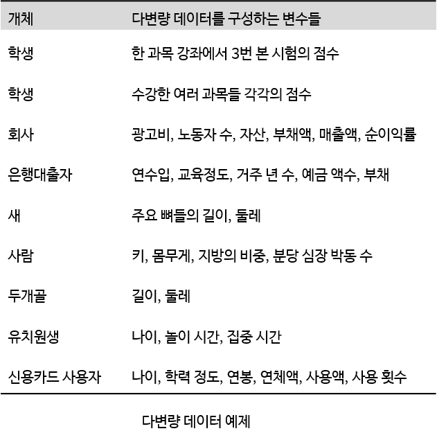

- 다변량 분석(Multivariate Analysis) : 다변량 데이터를 이용하여 `변수들 간의 관계성을 동시에 분석`하는 통계적 분석
  - 각 변수에 대한 개별적인 일변량 분석을 개선한 분석
- 다변량 분석의 초기에는 다변량 방법의 응용에 포함된 방대한 계산량의 부담으로 그 적용에 많은 제한을 받아왔으며, 주로 선형대수학을 비롯한 수학적인 개발에 치중되었다.
- 그러나, 20세기 후반 컴퓨터의 급속한 발전은 기존의 다변량 분석의 실제적인 응용과 새로운 기법의 발전을 가져왔다.
- 21세기 초반에 이르러 컴퓨터의 능력이 매우 강력해져 대용량의 자료에 대한 처리가 가능해졌으며, 다변량 분석은 유전학, 영상, 천문학 등에서 발생하는 매우 방대한 데이터셋에 대해서도 적용될 수 있게 되었다.
- 대용량의 데이터를 처리하는 기법인 데이터마이닝의 영역에서도 다변량 분석기법들이 매우 중요한 역할을 담당하고 있다.

## **2-1. 다변량 분석의 목적**

1. 다변량 데이터 탐색을 통해 분포와 구조에 대한 정보는 얻는 것
2. 적절한 분석방법을 적용하여 데이터가 발생한 시스템 또는 모집단에 대해 의미 있는 결과를 도출하는 것
   - 변수들 간의 인과관계 : 회귀분석, 분산분석
   - 변수들 간의 상관관계를 분석하여 데이터 차원 축약 : 주성분분석, 인자분석
   - 개체들의 유사성에 의해 개체들을 분류 : 군집분석, 판별분석
3. 통계분석 결과들로 얻어진 통계량과 그래프 등 분석 결과들을 이용하여 적절한 해석으로 그 분야의 현상에 대해 알아내는 것

## **2-2. 다변량 데이터의 구조**

- 데이터 행렬 : $p(\ge2)$개의 변수에 대해 $n$개의 개체로부터 얻어진 다변량 데이터를 행렬로 표현한 것
  - 데이터 행렬을 $\mathbf{X}_{n\times p}$라고 할 때,
    - 행의 수 = 개체의 수
    - 열의 수 = 변수의 수
      $$\mathbf{X}_{n\times p} = \begin{pmatrix}
      & 변수1 & 변수2 & \ldots & 변수j & \ldots &
      변수p \\
      개체 1 & x_{11}& x_{12}& \ldots & x_{1j}& \ldots
      & x_{1p} \\
      개체 2 & x_{21}& x_{22}& \ldots & x_{2j}& \ldots
      & x_{2p}\\
      \vdots & \vdots& \vdots& \vdots & \vdots& \vdots
      & \vdots\\
      개체 i & x_{i1}& x_{i2}& \ldots & x_{ij}& \ldots
      & x_{ip}\\
      \vdots & \vdots& \vdots& \vdots & \vdots& \vdots
      & \vdots\\
      개체 n & x_{n1}& x_{n2}& \ldots & x_{nj}& \ldots
      & x_{np}
      \end{pmatrix}$$
    - $x_{ij}$ : $i$번째 개체에 대한 $j$번째 변수의 관측값
    - $i$번째 행은 $i$번째 개체에 대한 관측값들로 이루어진 행벡터
    - $j$번째 열은 $j$번째 변수에 대한 개체들의 관측값으로 이루어진 열벡터
      - 만약 변수들의 변이성이나 군집성 혹은 그들 간의 연관성 등에 관심이 있다면, 이는 곧 데이터 행렬의 열을 중심으로 살펴본다는 것을 의미한다.
      - 이런 관점에서 데이터 행렬은 $p$개의 열벡터 $\mathbf{X}_{j}=\left(x_{1j}, x_{2j}, \ldots, x_{ij}, \ldots, x_{nj}\right)^T,\; j=1, \ldots, p$를 이용하여 $\mathbf{X}_{n\times p} = (\mathbf{X}_{1}, \ldots, \mathbf{X}_{j}, \ldots, \mathbf{X}_{p})$로 표현할 수 있다.
  - 예를 들어, 10명의 학생들이 수강한 통계학개론($X_1$), R데이터분석($X_2$), 다변량자료분석($X_3$)의 중간고사 점수를 데이터 행렬 $\mathbf{X}$로 표현하면 다음과 같다.

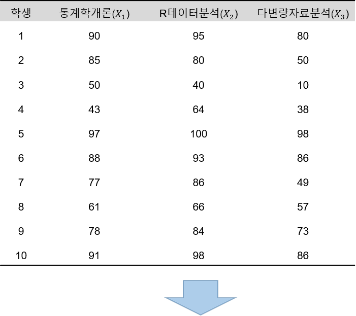

$$\;\;\;\;\;\;\;\;\;\;\;\;\;\;\;X_{1}\;\;\;\;X_{2}\;\;\;X_{3}\\
\mathbf{X}_{10\times 3} = \begin{pmatrix}
90 & 95 & 80\\
85 & 80 & 50\\
50 & 40 & 10\\
43 & 64 & 38\\
97 & 100 & 98\\
88 & 93 & 86\\
77 & 86 & 49\\
61 & 66 & 57 \\
78 & 84 & 73\\
91 & 98 & 86
\end{pmatrix} \tag{1}$$

## **2-3. 다변량 데이터의 요약**

- 데이터 행렬로부터 각 변수에 대한 기초적인 정보를 주는 기술통계량(Descriptive Statistics)을 계산할 수 있다.
  - 기술통계량의 예 : 평균, 분산, 공분산, 상관계수 등

### **2-3-1. 표본평균**

- $j$번째 변수의 표본평균 :
  $$\begin{align*}
  \bar{{x}}_{j} = \frac{1}{n}\sum_{i=1}^n x_{ij},\;\; j = 1, \ldots, p
  \end{align*}$$
  - $p$개의 표본평균들을 모아 하나의 벡터로 표현한 것을 표본평균벡터 $\bar{\mathbf{x}}=(\bar{{x}}_{1}, \ldots, \bar{{x}}_{j}, \ldots, \bar{{x}}_{p})^{T}=\frac{1}{n}\mathbf{X}^{T}\mathbf{1}$라고 한다.
  - 표본평균벡터는 $n$개 개체들의 중심으로 생각할 수 있다.
- 예를 들어, 데이터 행렬 (1)의 표본평균벡터는 $\bar{\mathbf{x}}=(76.0, 80.6, 62.7)^T= \begin{pmatrix}76.0\\80.6\\62.7\end{pmatrix}$.

[output not shown]

```
      [,1] [,2] [,3]
 [1,]   90   95   80
 [2,]   85   80   50
 [3,]   50   40   10
 [4,]   43   64   38
 [5,]   97  100   98
 [6,]   88   93   86
 [7,]   77   86   49
 [8,]   61   66   57
 [9,]   78   84   73
[10,]   91   98   86
```

```
apply(mat.x, 2, mean)
```

```
[1] 76.0 80.6 62.7
```

`Caution!` 함수 `apply()`는 주어진 함수를 특정 단위별로 쉽게 적용할 수 있도록 도움을 주는 함수이다. 첫 번째 인자로는 함수를 적용할 행렬 또는 데이터 프레임이 인자로 들어가고, 두 번째 인자로는 함수를 적용할 단위를 지정한다. 이때 “1”은 행 단위로 함수를 적용하고, “2”는 열 단위로 함수를 적용한다. 세 번째 인자는 적용할 함수를 지정하면 된다. 위의 코드 마지막 줄 `apply(mat.x, 2, mean)`은 행렬 “mat.x”의 열 단위로 평균을 적용하라는 의미이다.

### **2-3-2. 표본분산**

- $j$번째 변수의 표본분산 :
  $$\begin{align*}
  s_{j}^{2} = \frac{1}{n-1}\sum_{i=1}^n (x_{ij}-\bar{x}_{j})^2,\;\; j = 1,
  \ldots, p
  \end{align*}$$
  - 표본분산은 데이터 값들의 변동정도로서 데이터 값들이 평균으로부터 얼마나 떨어져 있는 지를 측정하는 측도이다.
  - 표본분산은 제곱의 합이기 때문에 측정단위도 원래의 측정단위의 제곱이 된다.
- 예를 들어, 데이터 행렬 (1)의 표본분산벡터는 $(342.4, 357.6, 722.9)^T=\begin{pmatrix}342.4\\357.6\\722.9\end{pmatrix}$.

[output not shown]

```
      [,1] [,2] [,3]
 [1,]   90   95   80
 [2,]   85   80   50
 [3,]   50   40   10
 [4,]   43   64   38
 [5,]   97  100   98
 [6,]   88   93   86
 [7,]   77   86   49
 [8,]   61   66   57
 [9,]   78   84   73
[10,]   91   98   86
```

```
apply(mat.x, 2, var)
```

```
[1] 342.4444 357.6000 722.9000
```

### **2-3-3. 표본표준편차**

- $j$번째 변수의 표본표준편차 :
  $$\begin{align*}
  s_{j}=\sqrt{s_{j}^2} = \sqrt{\frac{1}{n-1}\sum_{i=1}^n
  (x_{ij}-\bar{x}_{j})^2},\;\; j = 1, \ldots, p
  \end{align*}$$
  - 표본표준편차는 표본분산 $s_j^2$에 제곱근을 취해 원래의 측정단위와 같도록 만든 측도이다.
- 예를 들어, 데이터 행렬 (1)의 표본표준편차벡터는 $(18.5, 18.9, 26.9)^T=\begin{pmatrix}18.5\\18.9\\26.9\end{pmatrix}$.

[output not shown]

```
      [,1] [,2] [,3]
 [1,]   90   95   80
 [2,]   85   80   50
 [3,]   50   40   10
 [4,]   43   64   38
 [5,]   97  100   98
 [6,]   88   93   86
 [7,]   77   86   49
 [8,]   61   66   57
 [9,]   78   84   73
[10,]   91   98   86
```

```
apply(mat.x, 2, sd)
```

```
[1] 18.50525 18.91031 26.88680
```

### **2-3-4. 표본공분산**

- $j$번째 변수와 $k$번째 변수의 표본공분산 :
  $$\begin{align*}
  s_{jk} = s_{kj}=\frac{1}{n-1}\sum_{i=1}^n
  (x_{ij}-\bar{x}_{j})(x_{ik}-\bar{x}_{k}),\;\; j = 1, \ldots, p, \;\;, k=
  1, \ldots, p
  \end{align*}$$
  - 표본공분산은 두 변수 사이의 선형적 연관성을 측정한다.
    - 즉, $j$번째 변수에 대한 값의 증가에 따른 $k$번째 변수에 대한 값의 증가 또는 감소의 경향을 나타내는 측도이다.
    - $s_{jk}$가 큰 양의 값을 가지면 $j$번째 변수에 대한 값이 증가(감소)할 때 $k$번째 변수에 대한 값도 증가(감소)하는 경향이 있다.
    - $s_{jk}$가 큰 음의 값을 가지면 $j$번째 변수에 대한 값이 증가(감소)할 때 $k$번째 변수에 대한 값은 감소(증가)하는 경향이 있다.
    - $s_{jk}$가 0에 가까우면 두 변수의 증감은 서로 체계적인 경향이 없다는 것을 나타낸다.
      - 두 변수가 독립이면 $s_{jk} = 0$.
      - 하지만, $s_{jk} = 0$이라고 두 변수가 독립인 것은 아니다.
  - 표본공분산을 $p$개의 변수에 대한 행렬로 나타낸 표본공분산행렬은 다음과 같다.
    $$\mathbf{S}_{p\times p} = \begin{pmatrix}
    s_{11} = s_1^2& s_{12}& \ldots & s_{1j}& \ldots &
    s_{1p} \\
    s_{21}& s_{22} = s_2^2& \ldots & s_{2j}& \ldots &
    s_{2p}\\
    \vdots& \vdots& \vdots & \vdots& \vdots & \vdots\\
    s_{p1}& s_{p2}& \ldots & s_{pj}& \ldots & s_{pp} =
    s_p^2
    \end{pmatrix}$$
    - $s_{jk}=s_{kj}$이기 때문에 표본공분산행렬은 대칭행렬이다.
    - 대각성분은 각 변수들의 표준분산이다.
- R에서 표본공분산행렬은 함수 `cov()`를 이용하여 얻을 수 있다.

[output not shown]

```
      [,1] [,2] [,3]
 [1,]   90   95   80
 [2,]   85   80   50
 [3,]   50   40   10
 [4,]   43   64   38
 [5,]   97  100   98
 [6,]   88   93   86
 [7,]   77   86   49
 [8,]   61   66   57
 [9,]   78   84   73
[10,]   91   98   86
```

```
# 표본공분산행렬
cov(mat.x)
```

```
         [,1]     [,2]     [,3]
[1,] 342.4444 316.4444 419.5556
[2,] 316.4444 357.6000 469.9778
[3,] 419.5556 469.9778 722.9000
```

`Result!` 생성된 표본공분산행렬은 대칭행렬이며, 대각성분은 2-3-2. 표본분산에서 계산된 분산과 같다.

### **2-3-5. 표본상관계수**

- $j$번째 변수와 $k$번째 변수의 표본상관계수 :
  $$\begin{align*}
  r_{jk} = r_{kj}= \frac{s_{jk}}{s_js_k}= \frac{\sum_{i=1}^n
  (x_{ij}-\bar{x}_{j})(x_{ik}-\bar{x}_{k})}{\sqrt{\sum_{i=1}^n
  (x_{ij}-\bar{x}_{j})^2}\sqrt{\sum_{i=1}^n (x_{ik}-\bar{x}_{k})^2}},\;\;
  j = 1, \ldots, p, \;\;, k= 1, \ldots, p
  \end{align*}$$
  - 표본상관계수는 두 변수 사이의 선형성의 강도를 나타내는 측도로 흔히 사용된다.
  - 표본상관계수는 표본공분산을 표준화한 것과 같다.
    - 표본공분산은 변수들의 측정단위에 의존하며 그 값의 범위가 제한되어 있지 않아 크기를 상대비교하기가 어렵다.
    - 반면, 표본상관계수는 측정단위에 무관하고 $-1\le r_{jk} \le 1$이기 때문에 $1$ 또는 $-1$에 가까울수록 선형성의 강도가 큰 것을 의미한다.
      - $0 <r_{jk}\le 1$이면, $j$번째 변수에 대한 값이 증가(감소)할 때 $k$번째 변수에 대한 값도 증가(감소)하는 경향이 있으며, $1$에 가까울수록 강한 선형성을 보인다.
      - $-1 <r_{jk}< 0$이면, $j$번째 변수에 대한 값이 증가(감소)할 때 $k$번째 변수에 대한 값은 감소(증가)하는 경향이 있으며, $-1$에 가까울수록 강한 선형성을 보인다.
      - $r_{jk}=0$이면, 두 변수 사이의 선형관계는 존재하지 않는다.
  - 표본상관계수는 위치변환이나 척도변환 후에도 변하지 않는다.
  - 표본상관계수를 $p$개의 변수에 대한 행렬로 나타낸 표본상관행렬은 다음과 같다.
    $$\mathbf{R}_{p\times p} = \begin{pmatrix}
    1& r_{12}& \ldots & r_{1j}& \ldots & r_{1p} \\
    r_{21}& 1& \ldots & r_{2j}& \ldots & r_{2p}\\
    \vdots& \vdots& \vdots & \vdots& \vdots & \vdots\\
    r_{p1}& r_{p2}& \ldots & r_{pj}& \ldots & 1
    \end{pmatrix}$$
    - $r_{jk}=r_{kj}$이기 때문에 표본공분산행렬은 대칭행렬이다.
    - 대각성분은 1이다.
- R에서 표본상관행렬은 함수 `cor()`를 이용하여 얻을 수 있다.

[output not shown]

```
      [,1] [,2] [,3]
 [1,]   90   95   80
 [2,]   85   80   50
 [3,]   50   40   10
 [4,]   43   64   38
 [5,]   97  100   98
 [6,]   88   93   86
 [7,]   77   86   49
 [8,]   61   66   57
 [9,]   78   84   73
[10,]   91   98   86
```

```
# 표본상관행렬
cor(mat.x)
```

```
          [,1]      [,2]      [,3]
[1,] 1.0000000 0.9042815 0.8432480
[2,] 0.9042815 1.0000000 0.9243564
[3,] 0.8432480 0.9243564 1.0000000
```